# Wooldridge Ch2

Brendan Peek

## Ch 2 Answers

These are my answers to the end of chapter computer exercise C1 in Chapter 2 of Introductory Econometrics 5e by Jeffrey Wooldridge.

### C1

The variables in the dataset are:

1. prate - participation rate, percent
2. mrate - 401k plan match rate
3. totpart - total 401k participants
4. totelg - total eligible for 401k plan
5. age - age of 401k plan
6. totemp - total number of firm employees
7. sole - equal to 1 if 401k is firm’s sole plan
8. ltotemp - log of totemp

### i)

```r
mean(data$prate)
```

```
## [1] 87.36291
```

```r
mean(data$mrate)
```

```
## [1] 0.7315124
```

### ii)

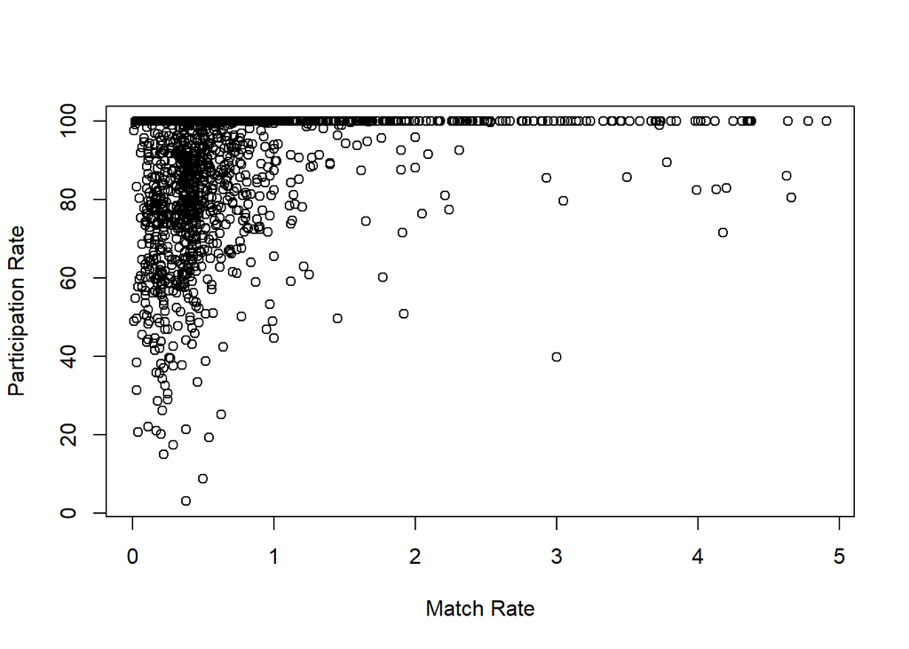

```r
participation.model <- lm(prate ~ mrate, data = data)
summary(participation.model)
```

```
##
## Call:
## lm(formula = prate ~ mrate, data = data)
##
## Residuals:
##     Min      1Q  Median      3Q     Max
## -82.303  -8.184   5.178  12.712  16.807
##
## Coefficients:
##             Estimate Std. Error t value Pr(>|t|)
## (Intercept)  83.0755     0.5633  147.48   <2e-16 ***
## mrate         5.8611     0.5270   11.12   <2e-16 ***
## ---
## Signif. codes:  0 '***' 0.001 '**' 0.01 '*' 0.05 '.' 0.1 ' ' 1
##
## Residual standard error: 16.09 on 1532 degrees of freedom
## Multiple R-squared:  0.0747, Adjusted R-squared:  0.0741
## F-statistic: 123.7 on 1 and 1532 DF,  p-value: < 2.2e-16
```

Sample size: 1534

R-squared: 0.075

### iii)

The intercept is 83.08 and the coefficient on mrate is 5.86. If the match rate is zero, the expected participation rate is 83.08%. The coefficient on mrate means that for each unit change in the match rate the expected participation rate changes by 5.86.

### iv)

```r
predict(participation.model, newdata = data.frame(mrate = 3.5))
```

```
##        1
## 103.5892
```

This doesn’t make sense because the participation rate cannot be greater than 100%. This is happening because we are using a model with no upper limit to predict an outcome with a limit at 100. The relationship does not appear to be linear so the model above is not appropriate.

### v)

The R-squared is very low at 0.075. The variation in the match rate does not explain much of the variation in the participation rate.